# Problem Statement

The purpose is to predict whether the Pima Indian women shows signs of diabetes or not. We are using a dataset collected by "National Institute of Diabetes and Digestive and Kidney Diseases" which consists of a number of attributes which would help us to perform this prediction.

**Constraints on data collection**

All patients whose data has been collected are females at least 21 years old of Pima Indian heritage

```python
#Import all the necessary modules
import pandas as pd
import numpy as np
import seaborn as sns
from sklearn.tree import DecisionTreeClassifier
from sklearn import metrics
```

# Q1. Load the PIMA Indian Diabetes file into Python DataFrame.

```python
data1= pd.read_csv('C:\\Users\\HP\\Downloads\\lab_3\\pima-indians-diabetes+(3).csv')
data1
```

|  | Preg | Plas | Pres | skin | test | mass | pedi | age | class |
| --- | --- | --- | --- | --- | --- | --- | --- | --- | --- |
| 0 | 6 | 148 | 72 | 35 | 0 | 33.6 | 0.627 | 50 | 1 |
| 1 | 1 | 85 | 66 | 29 | 0 | 26.6 | 0.351 | 31 | 0 |
| 2 | 8 | 183 | 64 | 0 | 0 | 23.3 | 0.672 | 32 | 1 |
| 3 | 1 | 89 | 66 | 23 | 94 | 28.1 | 0.167 | 21 | 0 |
| 4 | 0 | 137 | 40 | 35 | 168 | 43.1 | 2.288 | 33 | 1 |
| 5 | 5 | 116 | 74 | 0 | 0 | 25.6 | 0.201 | 30 | 0 |
| 6 | 3 | 78 | 50 | 32 | 88 | 31.0 | 0.248 | 26 | 1 |
| 7 | 10 | 115 | 0 | 0 | 0 | 35.3 | 0.134 | 29 | 0 |
| 8 | 2 | 197 | 70 | 45 | 543 | 30.5 | 0.158 | 53 | 1 |
| 9 | 8 | 125 | 96 | 0 | 0 | 0.0 | 0.232 | 54 | 1 |
| 10 | 4 | 110 | 92 | 0 | 0 | 37.6 | 0.191 | 30 | 0 |
| 11 | 10 | 168 | 74 | 0 | 0 | 38.0 | 0.537 | 34 | 1 |
| 12 | 10 | 139 | 80 | 0 | 0 | 27.1 | 1.441 | 57 | 0 |
| 13 | 1 | 189 | 60 | 23 | 846 | 30.1 | 0.398 | 59 | 1 |
| 14 | 5 | 166 | 72 | 19 | 175 | 25.8 | 0.587 | 51 | 1 |
| 15 | 7 | 100 | 0 | 0 | 0 | 30.0 | 0.484 | 32 | 1 |
| 16 | 0 | 118 | 84 | 47 | 230 | 45.8 | 0.551 | 31 | 1 |
| 17 | 7 | 107 | 74 | 0 | 0 | 29.6 | 0.254 | 31 | 1 |
| 18 | 1 | 103 | 30 | 38 | 83 | 43.3 | 0.183 | 33 | 0 |
| 19 | 1 | 115 | 70 | 30 | 96 | 34.6 | 0.529 | 32 | 1 |
| 20 | 3 | 126 | 88 | 41 | 235 | 39.3 | 0.704 | 27 | 0 |
| 21 | 8 | 99 | 84 | 0 | 0 | 35.4 | 0.388 | 50 | 0 |
| 22 | 7 | 196 | 90 | 0 | 0 | 39.8 | 0.451 | 41 | 1 |
| 23 | 9 | 119 | 80 | 35 | 0 | 29.0 | 0.263 | 29 | 1 |
| 24 | 11 | 143 | 94 | 33 | 146 | 36.6 | 0.254 | 51 | 1 |
| 25 | 10 | 125 | 70 | 26 | 115 | 31.1 | 0.205 | 41 | 1 |
| 26 | 7 | 147 | 76 | 0 | 0 | 39.4 | 0.257 | 43 | 1 |
| 27 | 1 | 97 | 66 | 15 | 140 | 23.2 | 0.487 | 22 | 0 |
| 28 | 13 | 145 | 82 | 19 | 110 | 22.2 | 0.245 | 57 | 0 |
| 29 | 5 | 117 | 92 | 0 | 0 | 34.1 | 0.337 | 38 | 0 |
| ... | ... | ... | ... | ... | ... | ... | ... | ... | ... |
| 738 | 2 | 99 | 60 | 17 | 160 | 36.6 | 0.453 | 21 | 0 |
| 739 | 1 | 102 | 74 | 0 | 0 | 39.5 | 0.293 | 42 | 1 |
| 740 | 11 | 120 | 80 | 37 | 150 | 42.3 | 0.785 | 48 | 1 |
| 741 | 3 | 102 | 44 | 20 | 94 | 30.8 | 0.400 | 26 | 0 |
| 742 | 1 | 109 | 58 | 18 | 116 | 28.5 | 0.219 | 22 | 0 |
| 743 | 9 | 140 | 94 | 0 | 0 | 32.7 | 0.734 | 45 | 1 |
| 744 | 13 | 153 | 88 | 37 | 140 | 40.6 | 1.174 | 39 | 0 |
| 745 | 12 | 100 | 84 | 33 | 105 | 30.0 | 0.488 | 46 | 0 |
| 746 | 1 | 147 | 94 | 41 | 0 | 49.3 | 0.358 | 27 | 1 |
| 747 | 1 | 81 | 74 | 41 | 57 | 46.3 | 1.096 | 32 | 0 |
| 748 | 3 | 187 | 70 | 22 | 200 | 36.4 | 0.408 | 36 | 1 |
| 749 | 6 | 162 | 62 | 0 | 0 | 24.3 | 0.178 | 50 | 1 |
| 750 | 4 | 136 | 70 | 0 | 0 | 31.2 | 1.182 | 22 | 1 |
| 751 | 1 | 121 | 78 | 39 | 74 | 39.0 | 0.261 | 28 | 0 |
| 752 | 3 | 108 | 62 | 24 | 0 | 26.0 | 0.223 | 25 | 0 |
| 753 | 0 | 181 | 88 | 44 | 510 | 43.3 | 0.222 | 26 | 1 |
| 754 | 8 | 154 | 78 | 32 | 0 | 32.4 | 0.443 | 45 | 1 |
| 755 | 1 | 128 | 88 | 39 | 110 | 36.5 | 1.057 | 37 | 1 |
| 756 | 7 | 137 | 90 | 41 | 0 | 32.0 | 0.391 | 39 | 0 |
| 757 | 0 | 123 | 72 | 0 | 0 | 36.3 | 0.258 | 52 | 1 |
| 758 | 1 | 106 | 76 | 0 | 0 | 37.5 | 0.197 | 26 | 0 |
| 759 | 6 | 190 | 92 | 0 | 0 | 35.5 | 0.278 | 66 | 1 |
| 760 | 2 | 88 | 58 | 26 | 16 | 28.4 | 0.766 | 22 | 0 |
| 761 | 9 | 170 | 74 | 31 | 0 | 44.0 | 0.403 | 43 | 1 |
| 762 | 9 | 89 | 62 | 0 | 0 | 22.5 | 0.142 | 33 | 0 |
| 763 | 10 | 101 | 76 | 48 | 180 | 32.9 | 0.171 | 63 | 0 |
| 764 | 2 | 122 | 70 | 27 | 0 | 36.8 | 0.340 | 27 | 0 |
| 765 | 5 | 121 | 72 | 23 | 112 | 26.2 | 0.245 | 30 | 0 |
| 766 | 1 | 126 | 60 | 0 | 0 | 30.1 | 0.349 | 47 | 1 |
| 767 | 1 | 93 | 70 | 31 | 0 | 30.4 | 0.315 | 23 | 0 |

768 rows × 9 columns

```python
data1.columns
```

```
Index(['Preg', 'Plas', 'Pres', 'skin', 'test', 'mass', 'pedi', 'age', 'class'], dtype='object')
```

```python
data1.describe()
```

|  | Preg | Plas | Pres | skin | test | mass | pedi | age | class |
| --- | --- | --- | --- | --- | --- | --- | --- | --- | --- |
| count | 768.000000 | 768.000000 | 768.000000 | 768.000000 | 768.000000 | 768.000000 | 768.000000 | 768.000000 | 768.000000 |
| mean | 3.845052 | 120.894531 | 69.105469 | 20.536458 | 79.799479 | 31.992578 | 0.471876 | 33.240885 | 0.348958 |
| std | 3.369578 | 31.972618 | 19.355807 | 15.952218 | 115.244002 | 7.884160 | 0.331329 | 11.760232 | 0.476951 |
| min | 0.000000 | 0.000000 | 0.000000 | 0.000000 | 0.000000 | 0.000000 | 0.078000 | 21.000000 | 0.000000 |
| 25% | 1.000000 | 99.000000 | 62.000000 | 0.000000 | 0.000000 | 27.300000 | 0.243750 | 24.000000 | 0.000000 |
| 50% | 3.000000 | 117.000000 | 72.000000 | 23.000000 | 30.500000 | 32.000000 | 0.372500 | 29.000000 | 0.000000 |
| 75% | 6.000000 | 140.250000 | 80.000000 | 32.000000 | 127.250000 | 36.600000 | 0.626250 | 41.000000 | 1.000000 |
| max | 17.000000 | 199.000000 | 122.000000 | 99.000000 | 846.000000 | 67.100000 | 2.420000 | 81.000000 | 1.000000 |

```python
data1.median()
```

```
Preg       3.0000
Plas     117.0000
Pres      72.0000
skin      23.0000
test      30.5000
mass      32.0000
pedi       0.3725
age       29.0000
class      0.0000
dtype: float64
```

# Q2. Print 10 samples from the dataset

```python
data1.head(10)
```

|  | Preg | Plas | Pres | skin | test | mass | pedi | age | class |
| --- | --- | --- | --- | --- | --- | --- | --- | --- | --- |
| 0 | 6 | 148 | 72 | 35 | 0 | 33.6 | 0.627 | 50 | 1 |
| 1 | 1 | 85 | 66 | 29 | 0 | 26.6 | 0.351 | 31 | 0 |
| 2 | 8 | 183 | 64 | 0 | 0 | 23.3 | 0.672 | 32 | 1 |
| 3 | 1 | 89 | 66 | 23 | 94 | 28.1 | 0.167 | 21 | 0 |
| 4 | 0 | 137 | 40 | 35 | 168 | 43.1 | 2.288 | 33 | 1 |
| 5 | 5 | 116 | 74 | 0 | 0 | 25.6 | 0.201 | 30 | 0 |
| 6 | 3 | 78 | 50 | 32 | 88 | 31.0 | 0.248 | 26 | 1 |
| 7 | 10 | 115 | 0 | 0 | 0 | 35.3 | 0.134 | 29 | 0 |
| 8 | 2 | 197 | 70 | 45 | 543 | 30.5 | 0.158 | 53 | 1 |
| 9 | 8 | 125 | 96 | 0 | 0 | 0.0 | 0.232 | 54 | 1 |

# Q3 Print the datatypes of each column and the shape of the dataset

```python
data1.dtypes
```

```
Preg       int64
Plas       int64
Pres       int64
skin       int64
test       int64
mass     float64
pedi     float64
age        int64
class      int64
dtype: object
```

```python
data1.shape
```

```
(768, 9)
```

```python
# data1.isnull().sum() to check the null values
```

[output not shown]

There are '0's in the data. Are they really valid '0's or they are missing values? Plasma, BP, skin thickness etc. these values cannot be 0. look at column by column logically to understand this.

```python
# len(data1[data1['Preg']==0]) for one column  = 111
#len(data1[data1['Plas']==0])       = 5
#len(data1[data1['Pres']==0])     = 35
# len(data1[data1['skin']==0])
# len(data1[data1['test']==0])
# len(data1[data1['mass']==0])
# len(data1[data1['pedi']==0])
# len(data1[data1['age']==0])
data1.info()
```

```
<class 'pandas.core.frame.DataFrame'>
RangeIndex: 768 entries, 0 to 767
Data columns (total 9 columns):
Preg     768 non-null int64
Plas     768 non-null int64
Pres     768 non-null int64
skin     768 non-null int64
test     768 non-null int64
mass     768 non-null float64
pedi     768 non-null float64
age      768 non-null int64
class    768 non-null int64
dtypes: float64(2), int64(7)
memory usage: 54.1 KB
```

# Q4 Replace all the 0s in the column with the median of the same column value accordingly.

```python
data2 = data1.drop(['class','Preg'],axis=1 )
data2
```

|  | Plas | Pres | skin | test | mass | pedi | age |
| --- | --- | --- | --- | --- | --- | --- | --- |
| 0 | 148 | 72 | 35 | 0 | 33.6 | 0.627 | 50 |
| 1 | 85 | 66 | 29 | 0 | 26.6 | 0.351 | 31 |
| 2 | 183 | 64 | 0 | 0 | 23.3 | 0.672 | 32 |
| 3 | 89 | 66 | 23 | 94 | 28.1 | 0.167 | 21 |
| 4 | 137 | 40 | 35 | 168 | 43.1 | 2.288 | 33 |
| 5 | 116 | 74 | 0 | 0 | 25.6 | 0.201 | 30 |
| 6 | 78 | 50 | 32 | 88 | 31.0 | 0.248 | 26 |
| 7 | 115 | 0 | 0 | 0 | 35.3 | 0.134 | 29 |
| 8 | 197 | 70 | 45 | 543 | 30.5 | 0.158 | 53 |
| 9 | 125 | 96 | 0 | 0 | 0.0 | 0.232 | 54 |
| 10 | 110 | 92 | 0 | 0 | 37.6 | 0.191 | 30 |
| 11 | 168 | 74 | 0 | 0 | 38.0 | 0.537 | 34 |
| 12 | 139 | 80 | 0 | 0 | 27.1 | 1.441 | 57 |
| 13 | 189 | 60 | 23 | 846 | 30.1 | 0.398 | 59 |
| 14 | 166 | 72 | 19 | 175 | 25.8 | 0.587 | 51 |
| 15 | 100 | 0 | 0 | 0 | 30.0 | 0.484 | 32 |
| 16 | 118 | 84 | 47 | 230 | 45.8 | 0.551 | 31 |
| 17 | 107 | 74 | 0 | 0 | 29.6 | 0.254 | 31 |
| 18 | 103 | 30 | 38 | 83 | 43.3 | 0.183 | 33 |
| 19 | 115 | 70 | 30 | 96 | 34.6 | 0.529 | 32 |
| 20 | 126 | 88 | 41 | 235 | 39.3 | 0.704 | 27 |
| 21 | 99 | 84 | 0 | 0 | 35.4 | 0.388 | 50 |
| 22 | 196 | 90 | 0 | 0 | 39.8 | 0.451 | 41 |
| 23 | 119 | 80 | 35 | 0 | 29.0 | 0.263 | 29 |
| 24 | 143 | 94 | 33 | 146 | 36.6 | 0.254 | 51 |
| 25 | 125 | 70 | 26 | 115 | 31.1 | 0.205 | 41 |
| 26 | 147 | 76 | 0 | 0 | 39.4 | 0.257 | 43 |
| 27 | 97 | 66 | 15 | 140 | 23.2 | 0.487 | 22 |
| 28 | 145 | 82 | 19 | 110 | 22.2 | 0.245 | 57 |
| 29 | 117 | 92 | 0 | 0 | 34.1 | 0.337 | 38 |
| ... | ... | ... | ... | ... | ... | ... | ... |
| 738 | 99 | 60 | 17 | 160 | 36.6 | 0.453 | 21 |
| 739 | 102 | 74 | 0 | 0 | 39.5 | 0.293 | 42 |
| 740 | 120 | 80 | 37 | 150 | 42.3 | 0.785 | 48 |
| 741 | 102 | 44 | 20 | 94 | 30.8 | 0.400 | 26 |
| 742 | 109 | 58 | 18 | 116 | 28.5 | 0.219 | 22 |
| 743 | 140 | 94 | 0 | 0 | 32.7 | 0.734 | 45 |
| 744 | 153 | 88 | 37 | 140 | 40.6 | 1.174 | 39 |
| 745 | 100 | 84 | 33 | 105 | 30.0 | 0.488 | 46 |
| 746 | 147 | 94 | 41 | 0 | 49.3 | 0.358 | 27 |
| 747 | 81 | 74 | 41 | 57 | 46.3 | 1.096 | 32 |
| 748 | 187 | 70 | 22 | 200 | 36.4 | 0.408 | 36 |
| 749 | 162 | 62 | 0 | 0 | 24.3 | 0.178 | 50 |
| 750 | 136 | 70 | 0 | 0 | 31.2 | 1.182 | 22 |
| 751 | 121 | 78 | 39 | 74 | 39.0 | 0.261 | 28 |
| 752 | 108 | 62 | 24 | 0 | 26.0 | 0.223 | 25 |
| 753 | 181 | 88 | 44 | 510 | 43.3 | 0.222 | 26 |
| 754 | 154 | 78 | 32 | 0 | 32.4 | 0.443 | 45 |
| 755 | 128 | 88 | 39 | 110 | 36.5 | 1.057 | 37 |
| 756 | 137 | 90 | 41 | 0 | 32.0 | 0.391 | 39 |
| 757 | 123 | 72 | 0 | 0 | 36.3 | 0.258 | 52 |
| 758 | 106 | 76 | 0 | 0 | 37.5 | 0.197 | 26 |
| 759 | 190 | 92 | 0 | 0 | 35.5 | 0.278 | 66 |
| 760 | 88 | 58 | 26 | 16 | 28.4 | 0.766 | 22 |
| 761 | 170 | 74 | 31 | 0 | 44.0 | 0.403 | 43 |
| 762 | 89 | 62 | 0 | 0 | 22.5 | 0.142 | 33 |
| 763 | 101 | 76 | 48 | 180 | 32.9 | 0.171 | 63 |
| 764 | 122 | 70 | 27 | 0 | 36.8 | 0.340 | 27 |
| 765 | 121 | 72 | 23 | 112 | 26.2 | 0.245 | 30 |
| 766 | 126 | 60 | 0 | 0 | 30.1 | 0.349 | 47 |
| 767 | 93 | 70 | 31 | 0 | 30.4 | 0.315 | 23 |

768 rows × 7 columns

```python
# cols = [ 'Plas', 'Pres', 'skin', 'test', 'mass', 'pedi', 'age']
# for cols in data2:
#     if data2[cols] == 0:
#         data2[cols].replace(0,2)

data2 = data2.replace(0,data2.median())
data2
```

|  | Plas | Pres | skin | test | mass | pedi | age |
| --- | --- | --- | --- | --- | --- | --- | --- |
| 0 | 148 | 72 | 35 | 30.5 | 33.6 | 0.627 | 50 |
| 1 | 85 | 66 | 29 | 30.5 | 26.6 | 0.351 | 31 |
| 2 | 183 | 64 | 23 | 30.5 | 23.3 | 0.672 | 32 |
| 3 | 89 | 66 | 23 | 94.0 | 28.1 | 0.167 | 21 |
| 4 | 137 | 40 | 35 | 168.0 | 43.1 | 2.288 | 33 |
| 5 | 116 | 74 | 23 | 30.5 | 25.6 | 0.201 | 30 |
| 6 | 78 | 50 | 32 | 88.0 | 31.0 | 0.248 | 26 |
| 7 | 115 | 72 | 23 | 30.5 | 35.3 | 0.134 | 29 |
| 8 | 197 | 70 | 45 | 543.0 | 30.5 | 0.158 | 53 |
| 9 | 125 | 96 | 23 | 30.5 | 32.0 | 0.232 | 54 |
| 10 | 110 | 92 | 23 | 30.5 | 37.6 | 0.191 | 30 |
| 11 | 168 | 74 | 23 | 30.5 | 38.0 | 0.537 | 34 |
| 12 | 139 | 80 | 23 | 30.5 | 27.1 | 1.441 | 57 |
| 13 | 189 | 60 | 23 | 846.0 | 30.1 | 0.398 | 59 |
| 14 | 166 | 72 | 19 | 175.0 | 25.8 | 0.587 | 51 |
| 15 | 100 | 72 | 23 | 30.5 | 30.0 | 0.484 | 32 |
| 16 | 118 | 84 | 47 | 230.0 | 45.8 | 0.551 | 31 |
| 17 | 107 | 74 | 23 | 30.5 | 29.6 | 0.254 | 31 |
| 18 | 103 | 30 | 38 | 83.0 | 43.3 | 0.183 | 33 |
| 19 | 115 | 70 | 30 | 96.0 | 34.6 | 0.529 | 32 |
| 20 | 126 | 88 | 41 | 235.0 | 39.3 | 0.704 | 27 |
| 21 | 99 | 84 | 23 | 30.5 | 35.4 | 0.388 | 50 |
| 22 | 196 | 90 | 23 | 30.5 | 39.8 | 0.451 | 41 |
| 23 | 119 | 80 | 35 | 30.5 | 29.0 | 0.263 | 29 |
| 24 | 143 | 94 | 33 | 146.0 | 36.6 | 0.254 | 51 |
| 25 | 125 | 70 | 26 | 115.0 | 31.1 | 0.205 | 41 |
| 26 | 147 | 76 | 23 | 30.5 | 39.4 | 0.257 | 43 |
| 27 | 97 | 66 | 15 | 140.0 | 23.2 | 0.487 | 22 |
| 28 | 145 | 82 | 19 | 110.0 | 22.2 | 0.245 | 57 |
| 29 | 117 | 92 | 23 | 30.5 | 34.1 | 0.337 | 38 |
| ... | ... | ... | ... | ... | ... | ... | ... |
| 738 | 99 | 60 | 17 | 160.0 | 36.6 | 0.453 | 21 |
| 739 | 102 | 74 | 23 | 30.5 | 39.5 | 0.293 | 42 |
| 740 | 120 | 80 | 37 | 150.0 | 42.3 | 0.785 | 48 |
| 741 | 102 | 44 | 20 | 94.0 | 30.8 | 0.400 | 26 |
| 742 | 109 | 58 | 18 | 116.0 | 28.5 | 0.219 | 22 |
| 743 | 140 | 94 | 23 | 30.5 | 32.7 | 0.734 | 45 |
| 744 | 153 | 88 | 37 | 140.0 | 40.6 | 1.174 | 39 |
| 745 | 100 | 84 | 33 | 105.0 | 30.0 | 0.488 | 46 |
| 746 | 147 | 94 | 41 | 30.5 | 49.3 | 0.358 | 27 |
| 747 | 81 | 74 | 41 | 57.0 | 46.3 | 1.096 | 32 |
| 748 | 187 | 70 | 22 | 200.0 | 36.4 | 0.408 | 36 |
| 749 | 162 | 62 | 23 | 30.5 | 24.3 | 0.178 | 50 |
| 750 | 136 | 70 | 23 | 30.5 | 31.2 | 1.182 | 22 |
| 751 | 121 | 78 | 39 | 74.0 | 39.0 | 0.261 | 28 |
| 752 | 108 | 62 | 24 | 30.5 | 26.0 | 0.223 | 25 |
| 753 | 181 | 88 | 44 | 510.0 | 43.3 | 0.222 | 26 |
| 754 | 154 | 78 | 32 | 30.5 | 32.4 | 0.443 | 45 |
| 755 | 128 | 88 | 39 | 110.0 | 36.5 | 1.057 | 37 |
| 756 | 137 | 90 | 41 | 30.5 | 32.0 | 0.391 | 39 |
| 757 | 123 | 72 | 23 | 30.5 | 36.3 | 0.258 | 52 |
| 758 | 106 | 76 | 23 | 30.5 | 37.5 | 0.197 | 26 |
| 759 | 190 | 92 | 23 | 30.5 | 35.5 | 0.278 | 66 |
| 760 | 88 | 58 | 26 | 16.0 | 28.4 | 0.766 | 22 |
| 761 | 170 | 74 | 31 | 30.5 | 44.0 | 0.403 | 43 |
| 762 | 89 | 62 | 23 | 30.5 | 22.5 | 0.142 | 33 |
| 763 | 101 | 76 | 48 | 180.0 | 32.9 | 0.171 | 63 |
| 764 | 122 | 70 | 27 | 30.5 | 36.8 | 0.340 | 27 |
| 765 | 121 | 72 | 23 | 112.0 | 26.2 | 0.245 | 30 |
| 766 | 126 | 60 | 23 | 30.5 | 30.1 | 0.349 | 47 |
| 767 | 93 | 70 | 31 | 30.5 | 30.4 | 0.315 | 23 |

768 rows × 7 columns

# Q5 Print the descriptive statistics of each & every column using describe() function

```python
data2.describe()
```

|  | Plas | Pres | skin | test | mass | pedi | age |
| --- | --- | --- | --- | --- | --- | --- | --- |
| count | 768.000000 | 768.000000 | 768.000000 | 768.000000 | 768.000000 | 768.000000 | 768.000000 |
| mean | 121.656250 | 72.386719 | 27.334635 | 94.652344 | 32.450911 | 0.471876 | 33.240885 |
| std | 30.438286 | 12.096642 | 9.229014 | 105.547598 | 6.875366 | 0.331329 | 11.760232 |
| min | 44.000000 | 24.000000 | 7.000000 | 14.000000 | 18.200000 | 0.078000 | 21.000000 |
| 25% | 99.750000 | 64.000000 | 23.000000 | 30.500000 | 27.500000 | 0.243750 | 24.000000 |
| 50% | 117.000000 | 72.000000 | 23.000000 | 31.250000 | 32.000000 | 0.372500 | 29.000000 |
| 75% | 140.250000 | 80.000000 | 32.000000 | 127.250000 | 36.600000 | 0.626250 | 41.000000 |
| max | 199.000000 | 122.000000 | 99.000000 | 846.000000 | 67.100000 | 2.420000 | 81.000000 |

```python
data1.describe()
```

|  | Preg | Plas | Pres | skin | test | mass | pedi | age | class |
| --- | --- | --- | --- | --- | --- | --- | --- | --- | --- |
| count | 768.000000 | 768.000000 | 768.000000 | 768.000000 | 768.000000 | 768.000000 | 768.000000 | 768.000000 | 768.000000 |
| mean | 3.845052 | 120.894531 | 69.105469 | 20.536458 | 79.799479 | 31.992578 | 0.471876 | 33.240885 | 0.348958 |
| std | 3.369578 | 31.972618 | 19.355807 | 15.952218 | 115.244002 | 7.884160 | 0.331329 | 11.760232 | 0.476951 |
| min | 0.000000 | 0.000000 | 0.000000 | 0.000000 | 0.000000 | 0.000000 | 0.078000 | 21.000000 | 0.000000 |
| 25% | 1.000000 | 99.000000 | 62.000000 | 0.000000 | 0.000000 | 27.300000 | 0.243750 | 24.000000 | 0.000000 |
| 50% | 3.000000 | 117.000000 | 72.000000 | 23.000000 | 30.500000 | 32.000000 | 0.372500 | 29.000000 | 0.000000 |
| 75% | 6.000000 | 140.250000 | 80.000000 | 32.000000 | 127.250000 | 36.600000 | 0.626250 | 41.000000 | 1.000000 |
| max | 17.000000 | 199.000000 | 122.000000 | 99.000000 | 846.000000 | 67.100000 | 2.420000 | 81.000000 | 1.000000 |

# Q6 See the distribution of 'Class' variable and plot it using appropriate graph.

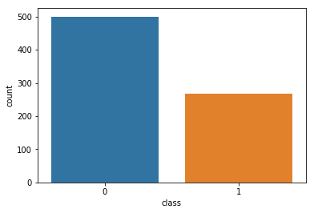

```python
sns.countplot(x='class', data=data1)
```

# Just for your understanding - Using univariate analysis check the individual attributes for their basic statistic such as central values, spread, tails etc. What are your observations (any two attributes). Its an optional step and will not be graded.

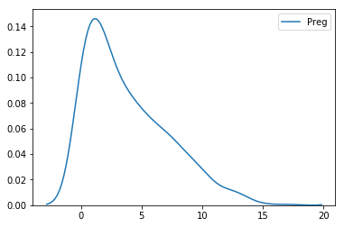

```python
#for cols in data1.columns:
sns.kdeplot(data1['Preg'])     #,data2=data1['Plas'])
```

# Q7. Use pairplots and correlation method to observe the relationship between different variables and state your insights.

Hint: Use seaborn plot and check the relationship between different variables

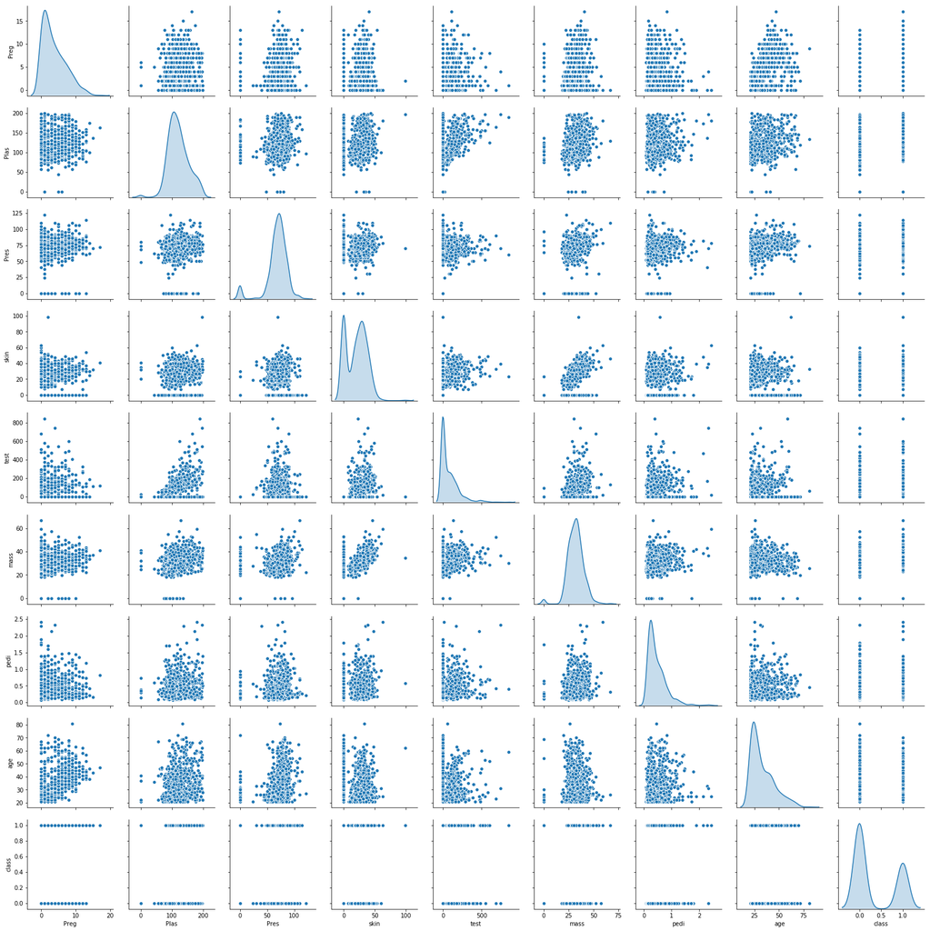

```python
sns.pairplot( data1,diag_kind ='kde')
```

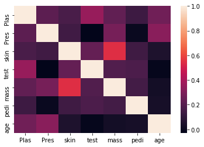

```python
sns.heatmap(data2.corr())
```

Using the plot - infer the relationship between different variables

# Q8 Split the pima_df into training and test set in the ratio of 70:30 (Training:Test).</b>

```python
X= data2
y=data1['class']
```

```python
from sklearn.model_selection import train_test_split
X_train,X_test,y_train,y_test = train_test_split(X,y,test_size= 0.3,random_state = 20)
```

# Q9 Create the decision tree model using “entropy” method of reducing the entropy and fit it to training data.</b>

```python
dt_model = DecisionTreeClassifier(criterion = 'entropy' )
dt_model.fit(X_train,y_train)
```

```
DecisionTreeClassifier(class_weight=None, criterion='entropy', max_depth=None,
            max_features=None, max_leaf_nodes=None,
            min_impurity_decrease=0.0, min_impurity_split=None,
            min_samples_leaf=1, min_samples_split=2,
            min_weight_fraction_leaf=0.0, presort=False, random_state=None,
            splitter='best')
```

# Q10 Print the accuracy of the model & print the confusion matrix

```python
predict_a= dt_model.predict(X_test)
print(dt_model.score(X_train,y_train))
print(dt_model.score(X_test,y_test))
print(metrics.confusion_matrix(y_test,predict_a))
```

```
1.0
0.696969696969697
[[111  42]
 [ 28  50]]
```

Print the feature importance of the decision model - Optional

```python
dt_model.feature_importances_
```

```
array([0.28200164, 0.08400302, 0.07149819, 0.0706753 , 0.22681253,
       0.13520738, 0.12980194])
```